# Differences in inaugural speeches between presidents from different parties

Jiaqi Dong jd3418

Inaugural speech is the first and one of the most important speech that a president tells people his political claims and what he is going to do for U.S. after he is elected. A president’s party may also influence his political claims and the way he speaks. Presidents from different parties may have some differences when they give the inaugural speech, like length of sentences and frequency of mentioning some certain words.

In this report, I use data of all the inaugural speeches of every U.S. presidents and split them into three groups: “Democratic”, “Republican” and “Others”. The length of sentences in their speeches of each group is analysed. The content of the short sentences are shown. And I also inspect a overall wordcloud to see what words are often mentioned for each group.

### Step 0: check and install needed packages. Load the libraries and functions.

```r
packages.used=c("rvest", "tibble", "qdap",
                "sentimentr", "gplots", "dplyr",
                "tm", "syuzhet", "factoextra",
                "beeswarm", "scales", "RColorBrewer",
                "RANN", "tm", "topicmodels",
                "wordcloud", "tidytext","xlsx")
# check packages that need to be installed.
packages.needed=setdiff(packages.used,
                        intersect(installed.packages()[,1],
                                  packages.used))
# install additional packages
if(length(packages.needed)>0){
  install.packages(packages.needed, dependencies = TRUE)
}
# load packages
library("rvest")
library("tibble")
library("qdap")
library("sentimentr")
library("gplots")
library("dplyr")
library("tm")
library("syuzhet")
library("factoextra")
library("beeswarm")
library("scales")
library("RColorBrewer")
library("RANN")
library("tm")
library("topicmodels")
library("wordcloud")
library("tidytext")
library("xlsx")
source("../lib/plotstacked.R")
source("../lib/speechFuncs.R")
```

This notebook was prepared with the following environmental settings.

```r
print(R.version)
```

```
               _
platform       x86_64-apple-darwin15.6.0
arch           x86_64
os             darwin15.6.0
system         x86_64, darwin15.6.0
status
major          3
minor          4.3
year           2017
month          11
day            30
svn rev        73796
language       R
version.string R version 3.4.3 (2017-11-30)
nickname       Kite-Eating Tree
```

### Step 1: Read in the speeches

First, let’s read in all the information about the presidents’names, parties and their speech contents. I deleted all the double quotes from the raw data because R fail to read the text everytime it meets a quote, that is why my speeches are read from the output folder.

```r
# Read inauguration information, which contains party.
inaug.info=read.xlsx("../data/InaugurationInfo.xlsx",header = T, sheetIndex = 1)
# Read in speeches
for(i in 1:nrow(inaug.info)){
  inaug.info$Filename[i]=paste0("inaug",inaug.info$File[i],"-",inaug.info$Term[i],".txt")
  inaug.info$Fulltext[i]=paste(readLines(paste0("../output/inauguralSpeeches/",
                                           inaug.info$Filename[i]),n=-1, skipNul=TRUE),
                               collapse = " ")
}
```

### Step 2:Data Processing — generate list of sentences

We will use sentences as units of analysis for this project, as sentences are natural languge units for organizing thoughts and ideas.

We assign an sequential id to each sentence in a speech (`sent.id`) and also calculated the number of words in each sentence as *sentence length* (`word.count`).

```r
# Detect sentences
sentence.list=NULL
for(i in 1:nrow(inaug.info)){
  sentences=sent_detect(inaug.info$Fulltext[i],
                        endmarks = c("?", ".", "!", "|",";"))
# Assign an sequential id and calculate the number of words
  if(length(sentences)>0){
    word.count=word_count(sentences)
    sentence.list=rbind(sentence.list,
                        cbind(inaug.info[i,-ncol(inaug.info)],
                              sentences=as.character(sentences),
                              word.count,
                              sent.id=1:length(sentences)
                              )
    )
  }
}
```

Some non-sentences exist in raw data due to erroneous extra end-of sentence marks.

```r
# Remove the zero-length sentences
sentence.list=
  sentence.list%>%
  filter(!is.na(word.count))
```

### Step 3: Data analysis — length of sentences

#### Democratic Party

First, let’s look at the sentence length distribution of presidents from Democratic Party.

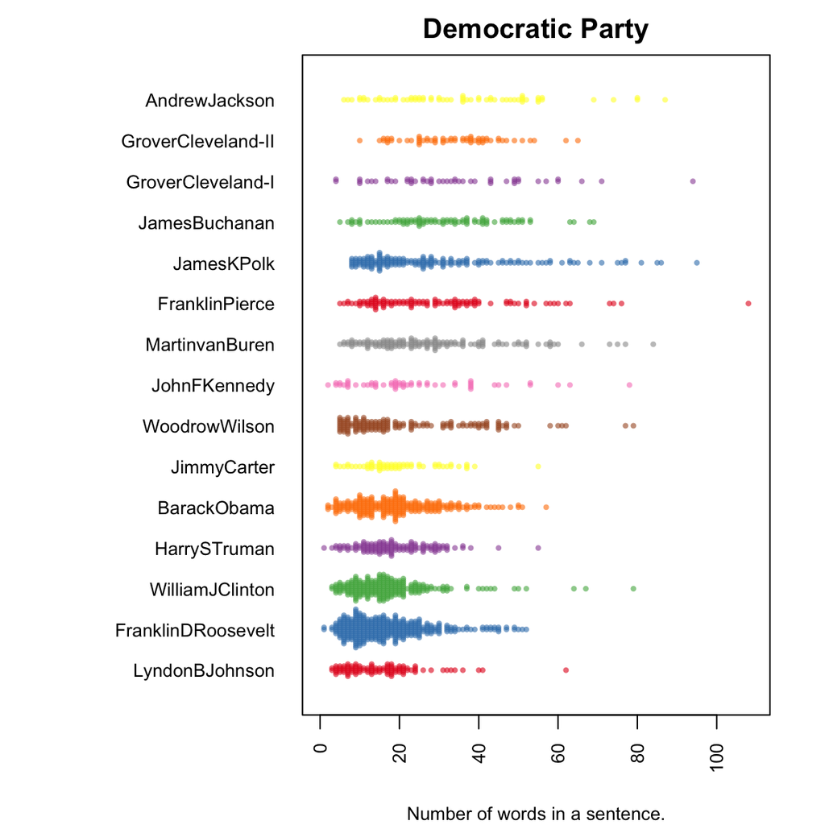

```r
par(mar=c(4, 11, 2, 2))
sentence.list.sel=filter(sentence.list,
                        Party=="Democratic")
sentence.list.sel$File=factor(sentence.list.sel$File)
sentence.list.sel$FileOrdered=reorder(sentence.list.sel$File,
                                  sentence.list.sel$word.count,
                                  mean,
                                  order=T)
beeswarm(word.count~FileOrdered,
         data=sentence.list.sel,
         horizontal = TRUE,
         pch=16, col=alpha(brewer.pal(9, "Set1"), 0.6),
         cex=0.55, cex.axis=0.8, cex.lab=0.8,
         spacing=5/nlevels(sentence.list.sel$FileOrdered),
         las=2, xlab="Number of words in a sentence.", ylab="",
         main="Democratic Party")
```

We can see that only about 1/3 of them seems to have a perference on speaking shorter sentences.

#### Republican Party

Then, let’s look at length of snetences in the speeches given by presidents from Republican Party.

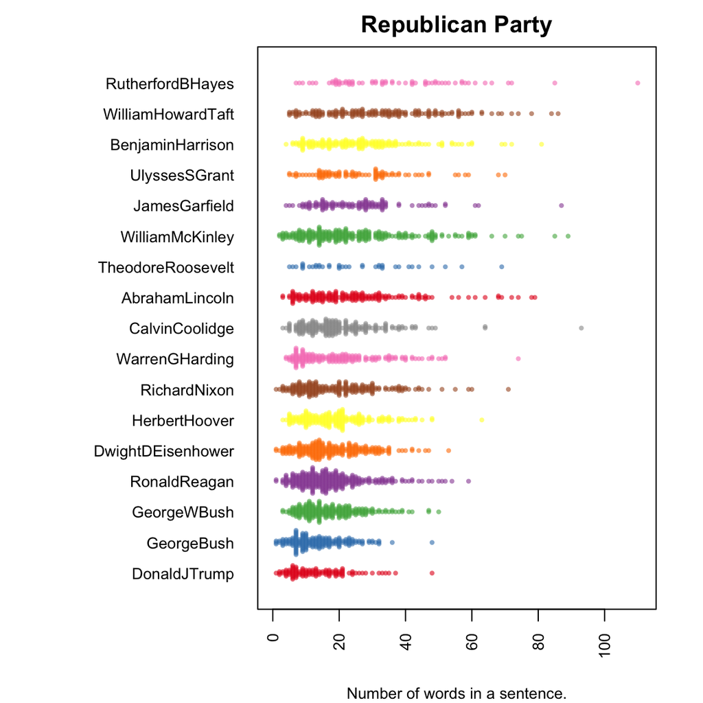

```r
par(mar=c(4, 11, 2, 2))
sentence.list.sel=filter(sentence.list,
                        Party=="Republican")
sentence.list.sel$File=factor(sentence.list.sel$File)
sentence.list.sel$FileOrdered=reorder(sentence.list.sel$File,
                                  sentence.list.sel$word.count,
                                  mean,
                                  order=T)
beeswarm(word.count~FileOrdered,
         data=sentence.list.sel,
         horizontal = TRUE,
         pch=16, col=alpha(brewer.pal(9, "Set1"), 0.6),
         cex=0.55, cex.axis=0.8, cex.lab=0.8,
         spacing=5/nlevels(sentence.list.sel$FileOrdered),
         las=2, xlab="Number of words in a sentence.", ylab="",
         main="Republican Party")
```

Unlike those from Democratic Party, about half of the presidents from Republican Party prefers speaking shorter sentences while giving their inaugural speech.

#### Other parties

Finally, let’s look at presidents from other parties.

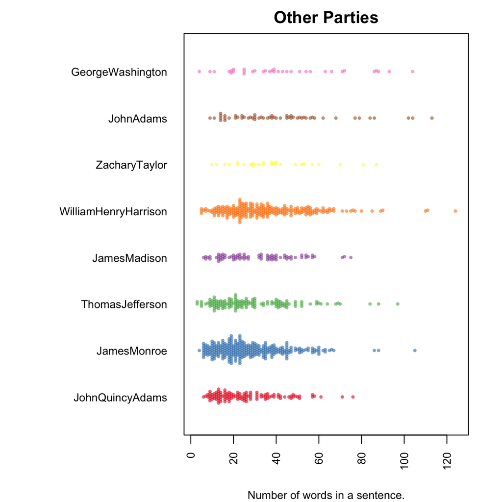

```r
party.other=c("NA","Fedralist","Democratic-Republican Party","Whig")
par(mar=c(4, 11, 2, 2))
sentence.list.sel=filter(sentence.list,
                        Party%in%party.other)
sentence.list.sel$File=factor(sentence.list.sel$File)
sentence.list.sel$FileOrdered=reorder(sentence.list.sel$File,
                                  sentence.list.sel$word.count,
                                  mean,
                                  order=T)
beeswarm(word.count~FileOrdered,
         data=sentence.list.sel,
         horizontal = TRUE,
         pch=16, col=alpha(brewer.pal(9, "Set1"), 0.6),
         cex=0.55, cex.axis=0.8, cex.lab=0.8,
         spacing=5/nlevels(sentence.list.sel$FileOrdered),
         las=2, xlab="Number of words in a sentence.", ylab="",
         main="Other Parties")
```

### Step 4: Data analysis — content of short sentences

Let’s now look at content in these short sentences from presidents of different parties.

```r
sentence.list%>%
  filter(Party=="Democratic",
         word.count<=3)%>%
  select(sentences)
```

| sentences |
| --- |
| taxes have risen; |
| deeply, \| |
| Mr. |
| Chief Justice, Mr. |
| Mr. |
| Vice President, Mr. |
| Speaker, Mr. |
| It was self-government. |
| We say farewell. |
| Investment is mobile. |

[output cut: 5 more lines]

```r
sentence.list%>%
  filter(Party=="Republican",
         word.count<=3)%>%
  select(sentences)
```

| sentences |
| --- |
| I think not. |
| Unanimity is impossible. |
| None exists now. |
| It became inevitable; |
| It came. |
| We are reunited. |
| Sectionalism has disappeared. |
| They are inconvenient. |
| They triumphed. |
| That verdict stands. |

[output cut: 38 more lines]

```r
# Other parties short sentence content
sentence.list%>%
  filter(Party%in%party.other,
         word.count<=3)%>%
  select(sentences)
```

[output not shown]

### Step 5: Inspect an overall wordcloud for each group

#### Democratic Party

```r
sentence.list.D=filter(sentence.list,
                        Party=="Democratic")
corpus.list=sentence.list.D[2:(nrow(sentence.list.D)-1), ]
sentence.pre=sentence.list.D$sentences[1:(nrow(sentence.list.D)-2)]
sentence.post=sentence.list.D$sentences[3:(nrow(sentence.list.D)-1)]
corpus.list$snipets=paste(sentence.pre, corpus.list$sentences, sentence.post, sep=" ")
rm.rows=(1:nrow(corpus.list))[corpus.list$sent.id==1]
rm.rows=c(rm.rows, rm.rows-1)
corpus.list=corpus.list[-rm.rows, ]
docs <- Corpus(VectorSource(corpus.list$snipets))
#remove potentially problematic symbols
docs <-tm_map(docs,content_transformer(tolower))
#remove punctuation
docs <- tm_map(docs, removePunctuation)
#Strip digits
docs <- tm_map(docs, removeNumbers)
#remove stopwords
docs <- tm_map(docs, removeWords, stopwords("english"))
#remove whitespace
docs <- tm_map(docs, stripWhitespace)
#Stem document
docs <- tm_map(docs,stemDocument)
tdm.all<-TermDocumentMatrix(docs)
tdm.tidy=tidy(tdm.all)
tdm.overall=summarise(group_by(tdm.tidy, term), sum(count))
```

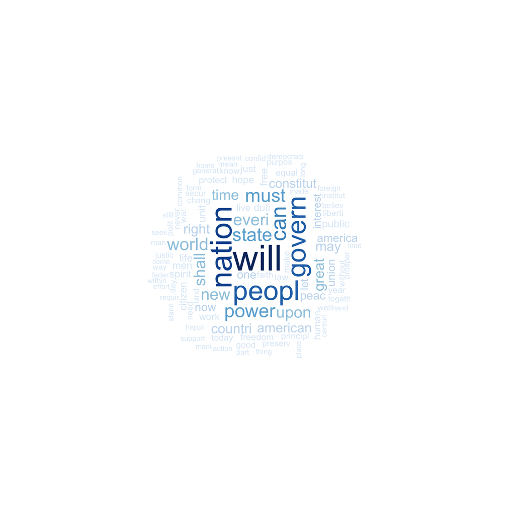

```r
wordcloud(tdm.overall$term, tdm.overall$`sum(count)`,
          scale=c(5,0.5),
          max.words=100,
          min.freq=1,
          random.order=FALSE,
          rot.per=0.3,
          use.r.layout=T,
          random.color=FALSE,
          colors=brewer.pal(9,"Blues"))
```

#### Republican Party

```r
sentence.list.R=filter(sentence.list,
                        Party=="Republican")
corpus.list=sentence.list.R[2:(nrow(sentence.list.R)-1), ]
sentence.pre=sentence.list.R$sentences[1:(nrow(sentence.list.R)-2)]
sentence.post=sentence.list.R$sentences[3:(nrow(sentence.list.R)-1)]
corpus.list$snipets=paste(sentence.pre, corpus.list$sentences, sentence.post, sep=" ")
rm.rows=(1:nrow(corpus.list))[corpus.list$sent.id==1]
rm.rows=c(rm.rows, rm.rows-1)
corpus.list=corpus.list[-rm.rows, ]
docs <- Corpus(VectorSource(corpus.list$snipets))
#remove potentially problematic symbols
docs <-tm_map(docs,content_transformer(tolower))
#remove punctuation
docs <- tm_map(docs, removePunctuation)
#Strip digits
docs <- tm_map(docs, removeNumbers)
#remove stopwords
docs <- tm_map(docs, removeWords, stopwords("english"))
#remove whitespace
docs <- tm_map(docs, stripWhitespace)
#Stem document
docs <- tm_map(docs,stemDocument)
tdm.all<-TermDocumentMatrix(docs)
tdm.tidy=tidy(tdm.all)
tdm.overall=summarise(group_by(tdm.tidy, term), sum(count))
```

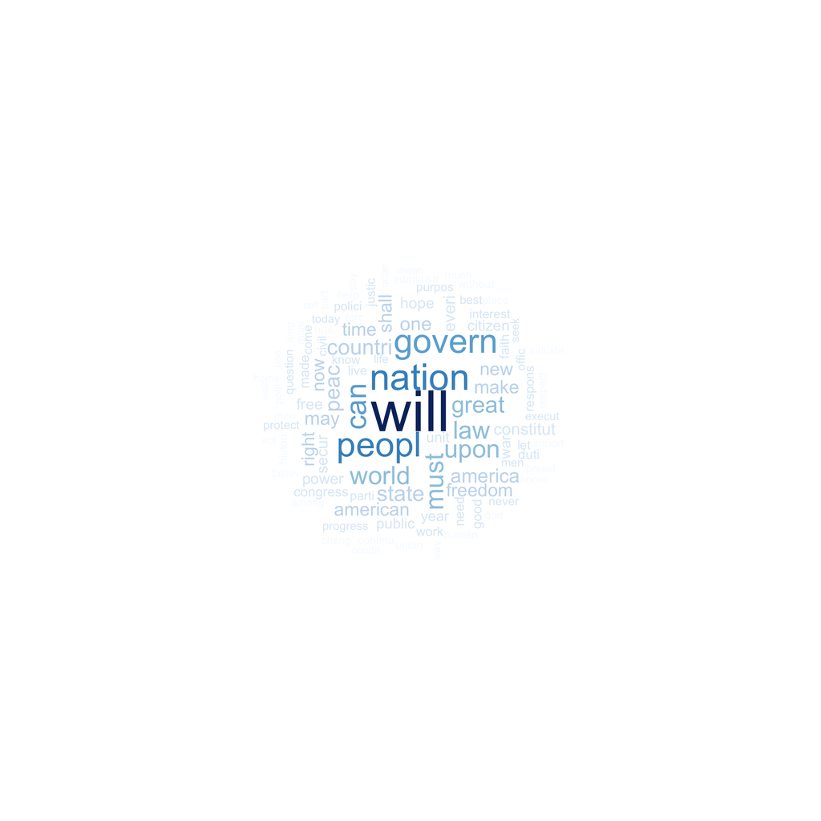

```r
wordcloud(tdm.overall$term, tdm.overall$`sum(count)`,
          scale=c(5,0.5),
          max.words=100,
          min.freq=1,
          random.order=FALSE,
          rot.per=0.3,
          use.r.layout=T,
          random.color=FALSE,
          colors=brewer.pal(9,"Blues"))
```

#### Other parties

```r
sentence.list.O=filter(sentence.list,
                        Party%in%party.other)
corpus.list=sentence.list.O[2:(nrow(sentence.list.O)-1), ]
sentence.pre=sentence.list.O$sentences[1:(nrow(sentence.list.O)-2)]
sentence.post=sentence.list.O$sentences[3:(nrow(sentence.list.O)-1)]
corpus.list$snipets=paste(sentence.pre, corpus.list$sentences, sentence.post, sep=" ")
rm.rows=(1:nrow(corpus.list))[corpus.list$sent.id==1]
rm.rows=c(rm.rows, rm.rows-1)
corpus.list=corpus.list[-rm.rows, ]
docs <- Corpus(VectorSource(corpus.list$snipets))
#remove potentially problematic symbols
docs <-tm_map(docs,content_transformer(tolower))
#remove punctuation
docs <- tm_map(docs, removePunctuation)
#Strip digits
docs <- tm_map(docs, removeNumbers)
#remove stopwords
docs <- tm_map(docs, removeWords, stopwords("english"))
#remove whitespace
docs <- tm_map(docs, stripWhitespace)
#Stem document
docs <- tm_map(docs,stemDocument)
tdm.all<-TermDocumentMatrix(docs)
tdm.tidy=tidy(tdm.all)
tdm.overall=summarise(group_by(tdm.tidy, term), sum(count))
```

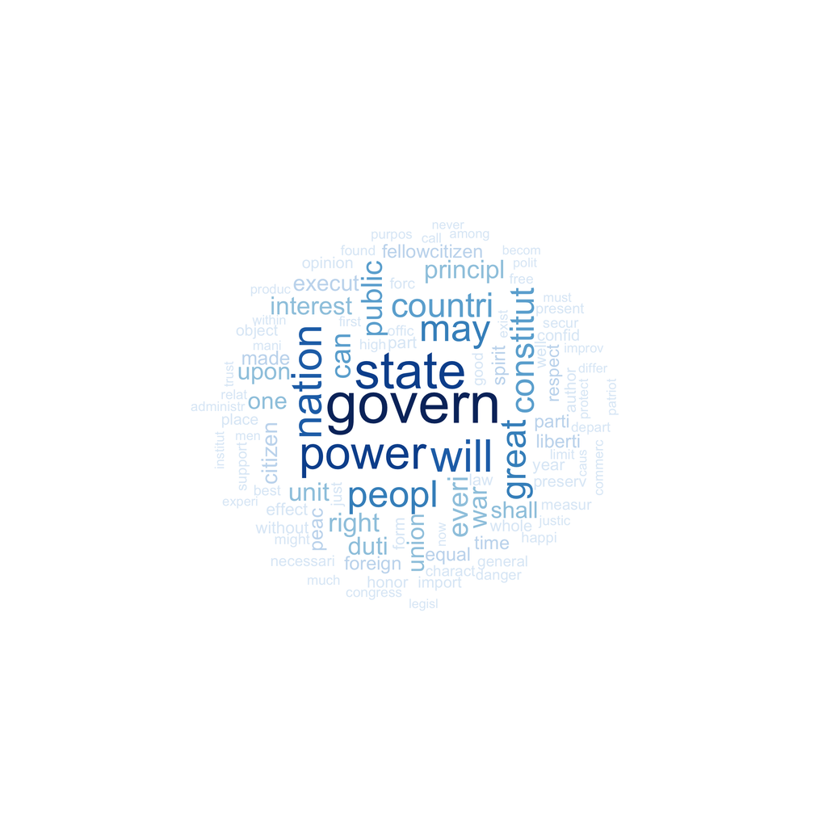

```r
wordcloud(tdm.overall$term, tdm.overall$`sum(count)`,
          scale=c(5,0.5),
          max.words=100,
          min.freq=1,
          random.order=FALSE,
          rot.per=0.3,
          use.r.layout=T,
          random.color=FALSE,
          colors=brewer.pal(9,"Blues"))
```

From the results we can notice many interesting things. Presidents from both Republican party and Democratic Party says “will” most, that means in the inaugural speech, they are telling people about their future plans and making promises. However, in the speeches of other presidents, they talk more about power, state, government, which means in their time, controling people well was the most important thing. What’s more, we can also see the word “law” appears much more often in speeches of presidents of Republican party than Democratic Party, which means that Republican party’s presidents seems pay more attention to legal construction.

### Summary

In this report, I use data of all the inaugural speeches of every U.S. presidents and split them into three groups: “Democratic”, “Republican” and “Others”. The length of sentences in their speeches of each group is analysed. The content of the short sentences are shown. And I also inspect a overall wordcloud to see what words are often mentioned for each group.

What’s more, presidents from both Republican party and Democratic Party says “will” most, that means in the inaugural speech, they are telling people about their future plans and making promises. However, in the speeches of other presidents, they talk more about power, state, government, which means in their time, controling people well was the most important thing. What’s more, we can also see the word “law” appears much more often in speeches of presidents of Republican party than Democratic Party, which means that Republican party’s presidents seems pay more attention to legal construction.